# Data visualisation, web scraping, and text analysis in R: Session 4

Text and sentiment analysis

J.M.T. Roos

Last updated: 2020-05-11 11:26:31

# This session

1. Basic text manipulation tools
   - REGEX
   - `stringr`
2. Dictionary-based approach to text analysis
   - `tm`
   - `tidytext`
3. Topic-based approach to text analysis
   - `lda`

# REGEX

- Short for **regular expression**
- A sequence of characters that define a **search pattern**
- Used to locate matches inside of strings of text
- Examples

| REGEX | Match(es) | Notes |
| --- | --- | --- |
| z | spoon7 | No matches |
| `.` | `s` `p` `o` `o` `n` `7` | Each character matches |
| `[sp]` | `s` `p` oon7 | `s` and `p` are matched separately |
| `sp` | `sp` oon7 | `sp` is matched as a whole |
| `sp\|on` | `sp` o `on` 7 | Means “or” |
| `[^sp]` | sp `o` `o` `n` `7` | `^` negates the set `[sp]` |
| `[m-q]` | s `p` `o` `o` `n` 7 | A range of characters |

# Repetitions

- In addition to matching single characters and literal strings, can also match **multiples** of patterns

| REGEX | Definition |
| --- | --- |
| `a*` | Zero or more a’s |
| `a+` | One or more a’s |
| `a?` | Zero or one a’s |
| `a{5}` | Exactly 5 a’s |
| `a{3,}` | 3 or more a’s |
| `a{1,3}` | Between 1 and 3 a’s |

- Matches are greedy: in ‘aaaa’, `a{2,4}` matches `aaaa` and not `aaa` or `aa`

[output not shown]

- These restrictions matter when you are using REGEX’s to define how to substitute new text in for old text

# Special characters

| Character | REGEX | Character | REGEX |
| --- | --- | --- | --- |
| `tab` | `\t` | `^` | `\^` |
| `new line` | `\n` | `$` | `\$` |
| `.` | `\.` | `[` | `\[` |
| `\` | `\\` | `]` | `\]` |
| `+` | `\+` | `(` | `\(` |
| `*` | `\*` | `)` | `\)` |
| `?` | `\?` | `/` | `\/` |
| `{` | `\{` | `}` | `\}` |

- In R, the backslash character `\` must be written as `\\` inside of strings

```r
cat("\\n")
```

```
## \n
```

- So to write `c:\` as a REGEX inside an R string, we write `c:\\\\`
- Four backslashes instead of 1? Really? Yes. Sorry.

# stringr

- The `stringr` package includes tools for detecting whether a string matches a REGEX pattern
  - The real work is performed by the `stringi` package, which is more flexible, but harder to work with
- `stringr::str_detect(s, r)` returns `TRUE` if `s` can be matched by `r`

```r
library(stringr)
s <- "This is the string to be matched"
r <- "m"
str_detect(s, r)
```

```
## [1] TRUE
```

```r
library(stringr)
s <- "This is the string to be matched"
r <- " [^ ] "
str_detect(s, r)
```

```
## [1] FALSE
```

- What does this REGEX mean?

```r
library(stringr)
s <- "This is the string to be matched"
r <- " [^ ]+ "
str_detect(s, r)
```

```
## [1] TRUE
```

- Why does this one match?
- `str_match(s, r)[[1]]` will return the portion of `s` that was matched by `r`

```r
s <- "This is the string to be matched"
r <- " [^ ]+ "
str_match(s, r)[[1]]
```

```
## [1] " is "
```

```r
r <- "(is ){2}"
str_match(s, r)[[1]]
```

```
## [1] "is is "
```

```r
r <- "(is )+?"
str_match(s, r)[[1]]
```

```
## [1] "is "
```

# Task

- Visit www.regexr.com
- Write a regular expression that matches all of the following words:
  - `Expression`
  - `expression`
  - `expressions`
- Your regular expression goes between `/` and `/g`
- When you’re done, write REGEX’s to match the following
  1. `Text` `text`
  2. `Save` `Favorites` but not `available`
  3. `Welcome` `RegExr` `Media` `Temple` `Edit` … and all words that begin with a capital letter, but no spaces or punctuation
  4. `testing` and `test` but no punctuation

# Task

```r
library(stringr)
s <- "This is hi$ fist"
```

- Write regular expressions in R using `str_match_all(s, r)` that produce the following matches

```
## [1] "is" "is" "is"
```

```
## [1] "is" "is" "i$" "is"
```

```
## [1] "his"  "fist"
```

# Text mining tools

- REGEX — for matching, extracting, and possibly transforming lines of text
  - `stringr` and `stringi` — operate over vectors of character strings
- `tm` — for applying the same extraction or transformation operations to large collections of text
  - For example, a set of documents, each of which is represented as a large character vector
  - Quickly generate and work with term-document matrices
  - `tidytext` provides a somewhat more `%>%`-friendly approach and has a free book that goes with it: http://tidytextmining.com
- `lda` — topical analysis of an already-cleaned collection of documents (e.g., previously prepared via `tm`)

# Text mining with `tm`

1. **Collect** – Organize texts from many sources in various formats in a single repository
2. **Clean** – Pre-process the texts to make them easier to work with
3. **Transform** – Generate numerical quantities based on the underlying texts for use in subsequent analysis
4. Subsequent analysis steps…

# The `tm` package

- The `Corpus` is a collection of related documents
  - Related documents are those that we want to analyze or transform or clean, all as a group
  - `tm` works with a variety of repository and file types (aka `Sources`)
  - When scraping data from the web, we typically just use a `VectorSource` (i.e., text are stored in character vectors)
- The `Document` is the basic unit of analysis, and might be a few short sentences (e.g., tweets) or a much longer text (e.g., a manuscript)
  - When specifying a `VectorSource`, each element of the character vector is considered a separate “document”
- The `TermDocumentMatrix` and `DocumentTermMatrix` are sparse matrices whose cells contain the number of co-occurances of each word in each document in the corpus

```r
library(tidyverse)
library(nuforc)
reports %>% select(reported, location, shape, report)
```

```
## # A tibble: 1,736 x 4
##    reported          location     shape   report
##    <chr>             <chr>        <chr>   <chr>
##  1 5/9/2019 7:46:06… Cincinnati,… "Trian… "Large V/triangle shaped craft that mov…
##  2 5/9/2019 7:59:49… Statesboro,… "Trian… "Two UFO's near Statesboro, Ga. 11:00 P…
##  3 5/8/2019 8:14:38… Norfolk, VA  "Light" "Extremely loud bang, light spotted in …
##  4 5/8/2019 6:42:52… Fremont, NH  "Other" "Very large floating aircraft with nav-…
##  5 5/8/2019 1:19:02… Saint Georg… "Other" "I started noticing a huge flash of lig…
##  6 5/8/2019 12:34:0… Highlands, … "Light" "I have about 10 recordings from last n…
##  7 5/7/2019 8:33:38… Palm Coast,… "Spher… "05/07/19 I saw 2 spheres inside were w…
##  8 5/9/2019 1:08:08… Mystic Isla… ""      "Radiant wide lights flashing three tim…
##  9 5/7/2019 7:26:23… Hobart, IN   "Other" "Absolutely still object, very large, h…
## 10 5/7/2019 5:27:22… Seattle, WA  "Light" "Ok so I'm just gonna say this happens …
## # … with 1,726 more rows
```

- For this example, we will focus on the full text report

```r
library(tm)
```

```r
ufo_corp <- Corpus(VectorSource(ufo_text)) %>%  # create corpus
  tm_map(content_transformer(tolower)) %>%      # lower case
  tm_map(removePunctuation) %>%                 # remove punctuation
  tm_map(removeWords, stopwords('english')) %>% # remove common words
  tm_map(stemDocument) %>%                      # reduce to word stems
  tm_map(stripWhitespace)                       # remove extra space
ufo_corp
```

```
## <<SimpleCorpus>>
## Metadata:  corpus specific: 1, document level (indexed): 0
## Content:  documents: 1625
```

```r
ufo_text[1557] %>% str_wrap %>% cat
```

```
## There was 3 consecutive flashes over the sky, almost like it was building up and
## the last one was almost like day time.
```

```r
tdm <- ufo_corp %>% TermDocumentMatrix
tdm_long <- with(tdm, tibble(term = i, document = j, count = v))
tdm_long
```

```
## # A tibble: 89,400 x 3
##     term document count
##    <int>    <int> <dbl>
##  1     1        1     1
##  2     2        1     1
##  3     3        1     1
##  4     4        1     1
##  5     5        1     1
##  6     6        1     1
##  7     7        1     1
##  8     8        1     1
##  9     9        1     1
## 10    10        1     1
## # … with 89,390 more rows
```

```r
inspect(tdm[1:10, 1:6])
```

```
## <<TermDocumentMatrix (terms: 10, documents: 6)>>
## Non-/sparse entries: 11/49
## Sparsity           : 82%
## Maximal term length: 6
## Weighting          : term frequency (tf)
## Sample             :
##         Docs
## Terms    1 2 3 4 5 6
##   1520   1 0 0 0 0 0
##   1520k  1 0 0 0 0 0
##   910    1 0 0 0 0 0
##   abrupt 1 0 0 0 0 0
##   along  1 0 0 0 0 0
##   awar   1 0 0 0 0 0
##   black  1 0 0 0 0 0
##   caught 1 0 0 0 0 0
##   chang  1 0 1 0 0 0
##   color  1 0 0 0 0 0
```

```r
inspect(tdm[535:545, 1:6])
```

```
## <<TermDocumentMatrix (terms: 11, documents: 6)>>
## Non-/sparse entries: 0/66
## Sparsity           : 100%
## Maximal term length: 8
## Weighting          : term frequency (tf)
## Sample             :
##           Docs
## Terms      1 2 3 4 5 6
##   auburn   0 0 0 0 0 0
##   closer   0 0 0 0 0 0
##   constant 0 0 0 0 0 0
##   eject    0 0 0 0 0 0
##   farther  0 0 0 0 0 0
##   flew     0 0 0 0 0 0
##   high     0 0 0 0 0 0
##   higher   0 0 0 0 0 0
##   lower    0 0 0 0 0 0
##   pretti   0 0 0 0 0 0
##   reddish  0 0 0 0 0 0
```

- Use `dplyr` to aggregate counts across documents

```r
tdm_long <- tdm_long %>% mutate(term = factor(term, labels = Terms(tdm)))
tdm_long %>% group_by(term) %>% summarise(count = sum(count)) %>%
  arrange(desc(count))
```

```
## # A tibble: 8,043 x 2
##    term   count
##    <fct>  <dbl>
##  1 light   3340
##  2 object  1612
##  3 sky     1608
##  4 look    1428
##  5 move    1389
##  6 like    1192
##  7 saw     1113
##  8 see     1006
##  9 bright   943
## 10 one      897
## # … with 8,033 more rows
```

- Alternative method to achieve same end from the `tidytext` package:

```r
tdm %>% tidytext::tidy()
```

```
## # A tibble: 89,400 x 3
##    term   document count
##    <chr>  <chr>    <dbl>
##  1 1520   1            1
##  2 1520k  1            1
##  3 910    1            1
##  4 abrupt 1            1
##  5 along  1            1
##  6 awar   1            1
##  7 black  1            1
##  8 caught 1            1
##  9 chang  1            1
## 10 color  1            1
## # … with 89,390 more rows
```

- Find terms that appear 400 times or more:

```r
tdm %>% findFreqTerms(400)
```

```
##  [1] "craft"     "disappear" "light"     "move"      "seem"      "shape"
##  [7] "sight"     "sound"     "wit"       "bright"    "fli"       "note"
## [13] "nuforc"    "object"    "one"       "red"       "saw"       "second"
## [19] "time"      "two"       "white"     "just"      "like"      "look"
## [25] "see"       "sky"       "night"     "seen"      "notic"     "appear"
## [31] "back"      "minut"     "around"    "first"     "watch"     "went"
## [37] "direct"    "star"      "east"
```

- Find terms that correlate with some other term

```r
tdm %>% findAssocs("shape", 0.25)  # cor(x,y) >= .25
```

```
## $shape
## cigar
##  0.27
```

```r
tdm %>% findAssocs("sky", 0.25)
```

```
## $sky
##  night   move object across second    see  clear
##   0.30   0.29   0.29   0.29   0.25   0.25   0.25
```

# More about `tidytext`

```r
library(tidytext)
tidy_reports <- tibble(report = ufo_text) %>% mutate(id = row_number()) %>%
    unnest_tokens(word, report)
tidy_reports
```

```
## # A tibble: 243,069 x 2
##       id word
##    <int> <chr>
##  1     1 large
##  2     1 v
##  3     1 triangle
##  4     1 shaped
##  5     1 craft
##  6     1 that
##  7     1 moved
##  8     1 silently
##  9     1 disappeared
## 10     1 at
## # … with 243,059 more rows
```

# Removing stop words with `tidytext`

```r
cleaned_reports <- tidy_reports %>% anti_join(get_stopwords(), by = "word")
```

```r
cleaned_reports %>% count(word, sort = TRUE)
```

```
## # A tibble: 9,890 x 2
##    word       n
##    <chr>  <int>
##  1 light   1696
##  2 lights  1636
##  3 sky     1574
##  4 object  1278
##  5 like    1211
##  6 saw     1115
##  7 bright   894
##  8 one      880
##  9 see      871
## 10 moving   807
## # … with 9,880 more rows
```

# “Bag-of-words” approaches to text tagging

- Main idea: If a word has a particular meaning and appears in a particular document, then the document conveys in some sense the meaning of that word
- Examples:
  - If many of the words in a sentence were (previously) measured as highly emotional (e.g., *extremely* and *hate*), we construe the sentence to be highly emotional
  - If a document contains many such sentences, we assume the document is highly emotional
- The order of words does not affect inferences (as if the words were dropped into a bag)
- Term-document matrices are inputs to bag-of-words analysis

# Scoring a term-document matrix

```r
words <- c("moving light night midnight minute white red pink orange yellow color star moon erratic flight slow wobble rotate hover pendulum speed eject shot climb dive") %>%
    stem_and_split()  # see .Rmd for source
```

- Sums occurrances of terms within each document (very quickly)

```r
tdm %>% tm_term_score(., words) %>% tibble(document = names(.), score = .)
```

```
## # A tibble: 1,625 x 2
##    document score
##    <chr>    <dbl>
##  1 1            6
##  2 2            8
##  3 3            7
##  4 4            3
##  5 5            1
##  6 6            5
##  7 7            8
##  8 8            8
##  9 9            8
## 10 10           5
## # … with 1,615 more rows
```

# Sentiment

- The bag-of-words approach can be used to measure the sentiment of documents in a corpus
- The current state of the art goes beyond the bag-of-words approach, taking advantage of word order, proximity to negating words, etc.
- But the underlying concept is the same — some words are highly positive or negative, and if they occur in a sentence, then the sentence is probably positive or negative

# Word lists

```r
word_scores_url <- "http://crr.ugent.be/papers/Ratings_Warriner_et_al.csv"
(words <- readr::read_csv(word_scores_url) %>% select(Word, valence = V.Mean.Sum,
    arousal = A.Mean.Sum, dominance = D.Mean.Sum))
```

```
## # A tibble: 13,915 x 4
##    Word        valence arousal dominance
##    <chr>         <dbl>   <dbl>     <dbl>
##  1 aardvark       6.26    2.41      4.27
##  2 abalone        5.3     2.65      4.95
##  3 abandon        2.84    3.73      3.32
##  4 abandonment    2.63    4.95      2.64
##  5 abbey          5.85    2.2       5
##  6 abdomen        5.43    3.68      5.15
##  7 abdominal      4.48    3.5       5.32
##  8 abduct         2.42    5.9       2.75
##  9 abduction      2.05    5.33      3.02
## 10 abide          5.52    3.26      5.33
## # … with 13,905 more rows
```

```r
words %>% gather(variable, value, -Word) %>% group_by(variable) %>% filter(percent_rank(value) >
    0.99) %>% ungroup %>% arrange(Word)
```

```
## # A tibble: 409 x 3
##    Word           variable  value
##    <chr>          <chr>     <dbl>
##  1 ablaze         arousal    6.75
##  2 acceleration   arousal    6.73
##  3 accomplish     dominance  7.27
##  4 accomplishment valence    8.05
##  5 achieve        valence    7.75
##  6 achievement    dominance  7.17
##  7 admire         dominance  7.33
##  8 advantage      dominance  7.19
##  9 adventurous    arousal    6.67
## 10 advocate       dominance  7.26
## # … with 399 more rows
```

# Arousal scores for word stems

```r
(arousal_stems <- words %>% select(Word, arousal) %>%
   mutate(term = stemDocument(Word)))
```

```
## # A tibble: 13,915 x 3
##    Word        arousal term
##    <chr>         <dbl> <chr>
##  1 aardvark       2.41 aardvark
##  2 abalone        2.65 abalon
##  3 abandon        3.73 abandon
##  4 abandonment    4.95 abandon
##  5 abbey          2.2  abbey
##  6 abdomen        3.68 abdomen
##  7 abdominal      3.5  abdomin
##  8 abduct         5.9  abduct
##  9 abduction      5.33 abduct
## 10 abide          3.26 abid
## # … with 13,905 more rows
```

# Merge scores and TDM

- Join scores with the term-document matrix (in long data frame form)

```r
tdm_long %>% inner_join(arousal_stems)
```

```
## # A tibble: 101,680 x 5
##    term   document count Word      arousal
##    <chr>     <int> <dbl> <chr>       <dbl>
##  1 abrupt        1     1 abrupt       5.23
##  2 awar          1     1 aware        4.7
##  3 awar          1     1 awareness    3.73
##  4 black         1     1 black        3.58
##  5 black         1     1 blackness    4.52
##  6 chang         1     1 change       4.05
##  7 color         1     1 color        3.18
##  8 color         1     1 colored      4.73
##  9 color         1     1 colorful     3.59
## 10 color         1     1 coloring     4.41
## # … with 101,670 more rows
```

# UFO report with highest arousal

- For each document, sum the arousal scores for any words in our list
- Arrange by score then print out the highest scoring report

```r
d <- tdm_long %>% inner_join(arousal_stems) %>% group_by(document) %>%
    summarise(score = sum(arousal)) %>% arrange(desc(score)) %>% top_n(1) %>%
    getElement("document")
ufo_text[d] %>% str_wrap(width = 70) %>% cat()
```

```
Interdimensional Beings Caught using thermal vision telescope and UFO
Fleet Over Alamance, NC I will address myself as anonymous and tell
my story. I had my first UFO sighting on Dec 11th observing 3 sphere
- stingray looking craft with discs rotating on both sides. I made
the assumption it would be a lucky one time pstanotmsl encounter,
but I think I have channeled and telepathically communicated with
inter-dimensionsal beings. Second day of significant sightings
included orbs thaf were rainbow in color ivy chi over nevada, a
flight tracker on delta airways, a TSA employee scribbling 669 on
my boarding pass had me like what is going on? Third sighting _
Feb 2 + 3rd 2019 (mothership, fleet of UFOs disguised in camouflage
when my galaxy focused camera. My phone had 95 percent battery,
overheated on a winter day and when I played my video clips back some
were unobtainable, but I got proof of a supernatural disturbance. I
consider it a blessing to be a witness of something so detailed and
incredibly amazing. the aliens, interdimensional beings, FBI drones
or CIA spying on me all are a definite possibility but I checked
the constellations via a new app on my phone and I have a live feed
of international space station. The ships continued to move every
time I would focus on them so I switched to AutoFocus attached a
fish eye lens and military grade binocular app to my camera. Both my
Nikon 5500 and my galaxy S9. I got a glimpse of 20 different ships.
Triangular craft with 3 spotlights (blue) a fireball ship hovering
low in the forest. I have seen to black helicopters during day and
two dogs went missing. I found ! a field where they are hovering above
taped off by swim team finish line rope and yellow tape. A random
crate was discovered by me and my cousin (huge shipping container)
with secret society occult written all over the unit. Triangle logos
dated in 1800 something. It said lumber 2015. Msde no sense. We found
wiccan esque area of occult materials and the following night I drove
past a hooded gathering of cloaked people at 4am by a bonfire in
the rain. Feb 25th I saw more vivid lights and got a telescope zoom
lens which allowed me to capture the saucer and prove the light was
some sort of spaceship or drone spinning. They hover NW and are also
close to mirzam under canis major left and down from Orion's belt.
The animals all start barking and I had made direct contact with
the aliens or interdimensional beings or angelic creatures (whatever
they are) via UHF device and I also have a device that can pick up
low frequencies. I bought a thermal sensor lens for camera to detect
heat signatures. March 1st - last night I discovered the entities
and spacecraft are only visible to those with their third eye open.
My mom can see it after I film it but she is programmed to think the
existence of aliens is some x-files shit. Whatever these UFO orbs
are they all the way visible from exit 154 by sheetz cookout and
the field is near mebane oaks road. I have contacted the town and no
military exercises were happening. Also I was vocal about sightings
at first and white Vans (literally like the show stranger things are
looking at me and watching my moves) too bad I'm an expert at evading
shadow government paid thugs. I contacted Mufon 3 times and have
been featured on numerous sites. Mebane NC ufo I pop up every time.
I definitely know some secret society is opening portals using blood
magic and adrenochrome or whatever it is they can levitate. I footage
of small beings talking to big beings and I think the humans might
be human trafficking for the aliens or smuggling somethin! g in that
crate. Its sketchy as hell to be honest. I got over 5000 video and
photos to prove it all too. That's the best part. Last night was the
closest the saucer has ever came and it wants to communicate to me for
sure. I get a feeling of more friendly than hostile but at 3am I'm up
staring at spaceships. Somebody needs to post my pictures man. I think
this is tied to CERN being activated as well as spirit realms 4th
5th dimension (David Icke type theories on reality being a simulated
matrix
```

# UFO reports with “lowest” arousal

```
* Entity seen.
* Una luz amarilla naranja que se hacia mas brillante y luego menos
  brillante, paso atraves de la ciudad y de ella salio otra luz pero
  esta era distinta y bajo a la montaña mientras la otra luz estaba
  estatica en el cielo. Luego cerca de 20 luces o mas subian y bajaban
  de la montaña, Tengo aproximadamente 8 min de video y fotos.
* A bunch of orbs and someone glowing.
* Flew quickly straight across sky from east to west.
* Luz branca brilhante do tamanho e luminosidade que avistamos o
  planeta Vênus percorrendo o céu com velocidade similar a da iss quando
  avistada. Direção noroeste sudeste; me certifiquei sobre a rota da iss
  no momento que era outra completamente diferente.
```

# `tidytext` approach (without stemming)

```r
cleaned_reports
```

```
## # A tibble: 125,952 x 2
##       id word
##    <int> <chr>
##  1     1 large
##  2     1 v
##  3     1 triangle
##  4     1 shaped
##  5     1 craft
##  6     1 moved
##  7     1 silently
##  8     1 disappeared
##  9     1 incredible
## 10     1 rate
## # … with 125,942 more rows
```

```r
scored_reports <- words %>% select(word = Word, arousal) %>% inner_join(cleaned_reports) %>%
    group_by(id) %>% summarise(arousal = sum(arousal))
```

# Bottom 5 based on sum of arousal score

```r
scored_reports %>% top_n(5, -arousal) %>% getElement("id") %>% ufo_text[.] %>%
    .[1:5] %>% str_trunc(width = 250) %>% str_wrap(width = 70, exdent = 2) %>%
    str_c("* ", .) %>% cat(sep = "\n")
```

```
## * Entity seen.
## * Light moving fast across sky and changed directions.
## * Seen a formation type of lights. Was there then disappeared after a
##   few minutes.
## * Round, flashing multi-colors, hovering than moving in different
##   directions.
## * A bunch of orbs and someone glowing.
```

# Top 5 based on sum of arousal score

```
## * Possible anti gravity propulsion system. First Reporting date:
##   9/24/1998 Reported to: Art Bell on Coast to Coast Show by fax. I would
##   like to take this opportunity to report a possible Unidentified Flying
##   Object [UFO]and share some insight into ...
## * Near Dayton OH red-orange object in night sky I'm nearly 40, with
##   a doctorate degree and a former university-level research assistant
##   to a professor of astrophysics. On this night, ny father was sitting
##   outside on our back patio in the dark, onl...
## * 1/13/19 close encounter with a 17'-20' tall Alien Robot Reporting on
##   my close encounter of the 3rd kind the early morning of January 13th,
##   2019. 1:30 AM I was sitting in my car while my dogs were out for a run
##   at large business campus locat...
## * Blue light incident and circular ufos On the fall, or winter of 2016,
##   possibly some time in October 2016, two of my step kids and I were
##   using an outdoor hot tub from a home that we were leasing in Yuma, AZ.
##   We were new to the Yuma, AZ area. We...
## * In 1967 I am a little kid now. I am sleeping I am awoke by movement. I
##   am so scared what is on my bed, something is moving. I am so hot, I do
##   not want to look. I must bring my head out from under the sheet. I am
##   so hot but I look any way. I ...
```

# Sentences instead of words

```r
d0 <- tibble(report = ufo_text) %>% mutate(id = row_number())
d1 <- d0 %>% unnest_tokens(sentence, report, token = "sentences")
d1
```

```
## # A tibble: 14,337 x 2
##       id sentence
##    <int> <chr>
##  1     1 large v/triangle shaped craft that moved silently.
##  2     1 disappeared at incredible rate of speed.
##  3     1 i was driving home when something very large in the eye caught my eye.
##  4     1 i was stopped at a light near my home and only got 15-20 secs of view.
##  5     1 the craft was very large v/triangle shape. 9-10 lights lining the v patt…
##  6     1 i heard no sound from the craft.
##  7     1 the craft was heading ne at an estimated 15-20k feet.
##  8     1 dark in color either black or dark gray.
##  9     1 it made 2 movements.
## 10     1 it seemed to descend rapidly and then abruptly shot out of sight along t…
## # … with 14,327 more rows
```

```r
d2 <- d1 %>% group_by(id) %>% mutate(sentence_id = row_number()) %>% unnest_tokens(word,
    sentence, token = "words") %>% ungroup()
d2
```

```
## # A tibble: 243,069 x 3
##       id sentence_id word
##    <int>       <int> <chr>
##  1     1           1 large
##  2     1           1 v
##  3     1           1 triangle
##  4     1           1 shaped
##  5     1           1 craft
##  6     1           1 that
##  7     1           1 moved
##  8     1           1 silently
##  9     1           2 disappeared
## 10     1           2 at
## # … with 243,059 more rows
```

# NRC sentiments

http://sentiment.nrc.ca/lexicons-for-research/

```r
head(surprise)
```

```
## # A tibble: 6 x 2
##   word         surprise
##   <chr>           <int>
## 1 abandonment         1
## 2 abduction           1
## 3 abrupt              1
## 4 accident            1
## 5 accidental          1
## 6 accidentally        1
```

```r
top_5_surprise <- d2 %>% left_join(surprise, by = "word") %>% mutate(surprise = coalesce(surprise,
    0L)) %>% group_by(id, sentence_id) %>% summarise(score = mean(surprise)) %>%
    ungroup() %>% group_by(id) %>% summarise(score = median(score)) %>%
    inner_join(d0, by = "id") %>% top_n(5, score) %>% arrange(desc(score))
```

# Top 5 based on surprise

```r
top_5_surprise %>% getElement("report") %>% # str_trunc(width = 250) %>%
str_wrap(width = 70, exdent = 2) %>% str_c("* ", .) %>% cat(sep = "\n")
```

```
## * A object only seen the light fly across sky and hover over tree
##   and then dips behind tree. Caught on video is a circular light that
##   appears to spin at times and somewhat fades. It flys slowly across
##   sky and then hovers over a tree and then hides behind tree and pops in
##   view a couple times, looks too big to be a drone.
## * Round UFO in the distant sky hovering then dropped straight down
##   behind the tree line at incredible speed. My daughter and I saw a
##   round yellow, pinkish colored ufo way in the distant sky...miles
##   away...hovering then suddenly dropped straight down behind the tree
##   line.
## * Large bright light stationery.. got larger then brighter.. then slowly
##   disappeared, whilst not moving at all
## * Three large orange red spheres in the sky slightly moving then all of
##   a sudden disappeared one by one.
## * was out with my dog facing south east mind you its cloudy winter storm
##   warnings in effect i cant even see the moon but these were hoovering
##   about 300 feet off the ground not a hoax you think iam filing a prank
##   its not funny to me to be scared to death or to see my dog scared
##   there here
```

# Latent Dirichlet allocation

- What are the topics of these sentences?

```r
txt <- c('Abe is funny',
         'Abe is fat',
         'Bob is fat',
         'Cam is fat',
         'Cam is funny',
         'Cam is short',
         'Dee is funny')
```

- Which of the following seems like the right set of main topics?

```
## [1] "cam"   "fat"   "abe"   "funny"
```

```
## [1] "fat"   "funny"
```

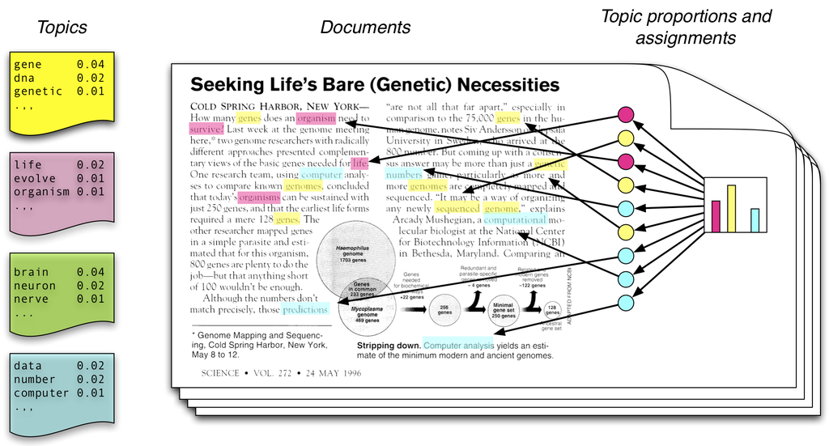

# `lda`

```r
library(lda)
lda_corp <- ufo_corp %>% plyr::laply(as.character) %>% str_replace("(^| )[0-9]( |$)",
    " [number] ") %>% str_replace("^ ", "") %>% lexicalize
K <- 14  # number of topics to detect
set.seed(1234)
fit <- lda.collapsed.gibbs.sampler(lda_corp$documents, K, lda_corp$vocab,
    500, 0.5, 0.1)
(top.words <- top.topic.words(fit$topics, 4, by.score = TRUE))
```

```
##      [,1]       [,2]    [,3]        [,4]       [,5]     [,6]    [,7]     [,8]
## [1,] "drive"    "orang" "sky"       "format"   "object" "light" "note"   "report"
## [2,] "car"      "orb"   "bright"    "triangl"  "east"   "hous"  "nuforc" "year"
## [3,] "road"     "glow"  "light"     "3"        "south"  "back"  "pd"     "rememb"
## [4,] "mountain" "ball"  "disappear" "[number]" "west"   "went"  "wit"    "said"
##      [,9]       [,10]     [,11]  [,12]    [,13]    [,14]
## [1,] "craft"    "sun"     "like" "light"  "video"  "object"
## [2,] "fli"      "moon"    "look" "red"    "pictur" "star"
## [3,] "sound"    "reflect" "see"  "flash"  "photo"  "sky"
## [4,] "aircraft" "saw"     "just" "bright" "phone"  "move"
```

```r
get_topic_names <- function(fit) {
    # code copied from lda::top.topic.words:
    normalized.topics <- fit$topics/(rowSums(fit$topics) + 1e-05)
    scores <- apply(normalized.topics, 2, function(x) x * (log(x + 1e-05) -
        sum(log(x + 1e-05))/length(x)))
    # end
    cutoff <- min(apply(scores, 1, function(x) max(x)))
    scores %>% as.data.frame %>% mutate(f = 1:nrow(.)) %>% gather(key,
        value, -f) %>% filter(value >= cutoff) %>% group_by(f) %>% arrange(f,
        desc(value)) %>% summarise(name = paste(key, collapse = " ")) %>%
        getElement("name")
}
get_topic_names(fit)
```

```
##  [1] "drive car"
##  [2] "orang orb glow ball sphere"
##  [3] "sky bright"
##  [4] "format triangl 3 [number] 2 triangular"
##  [5] "object"
##  [6] "light hous back"
##  [7] "note nuforc pd wit inform contact provid anonym elect total remain date"
##  [8] "report"
##  [9] "craft fli sound aircraft jet"
## [10] "sun"
## [11] "like look"
## [12] "light red flash bright one"
## [13] "video pictur photo phone camera object"
## [14] "object star sky move"
```

| name | top |
| --- | --- |
| drive car | Possible anti gravity propulsion system. First Reporting date: 9/24/199… |
| orang orb glow ball sphere | Saw 3 hovering orange, fuzzy glowing objects with no definition except w… |
| sky bright | Black oval object in sky flashing blue lights that “winked-out” followed… |
| format triangl 3 [number] 2 triangular | Estou localizado na região norte de São Paulo-SP, precisamente Avenida C… |
| object | Near Dayton OH red-orange object in night sky I’m nearly 40, with a doc… |
| light hous back | 1/13/19 close encounter with a 17’-20’ tall Alien Robot Reporting on my… |
| note nuforc pd wit inform contact provid anonym elect total remain date | Red Triangle UFO above a corn field (Bucks County flap). I was driving … |
| report | In 1967 I am a little kid now. I am sleeping I am awoke by movement. I… |
| craft fli sound aircraft jet | Possible anti gravity propulsion system. First Reporting date: 9/24/199… |
| sun | Ground based sighting on Georgia USA coast north of KSC, FL, possibly re… |
| like look | This happened in Bloomington, MN. I was driving on hwy 77 going north, … |
| light red flash bright one | Red & Green Blinking lights (Airplane imitation) & Later A Red & Green A… |
| video pictur photo phone camera object | crossing moon, disappear, reappear, hover then takeoff ((name of observ… |
| object star sky move | Near Dayton OH red-orange object in night sky I’m nearly 40, with a doc… |

- Assuming 5 topics rather than 14

| name | top |
| --- | --- |
| object east | Near Dayton OH red-orange object in night sky I’m nearly 40, with a doc… |
| object video | I saw a colored object slowly ascending while rotating along a very secl… |
| note nuforc pd inform provid contact wit anonym remain elect total sourc date indic report sight approxim | Estou localizado na região norte de São Paulo-SP, precisamente Avenida C… |
| look | 1/13/19 close encounter with a 17’-20’ tall Alien Robot Reporting on my… |
| light sky red bright move | Red & Green Blinking lights (Airplane imitation) & Later A Red & Green A… |

- No word stemming or stopword removal, and assuming 10 topics

| name | top |
| --- | --- |
| video | Interdimensional Beings Caught using thermal vision telescope and UFO Fl… |
| it i was | 1/13/19 close encounter with a 17’-20’ tall Alien Robot Reporting on my… |
| they were lights | 5 crafts- Hebron, Maryland at 9:30 pm on April, 27. 2019 On April 27, 2… |
| we our | UFO passes directly overhead at high speed in response to our flashlight… |
| note pd nuforc witness information contact provides totally elects remain anonymous no | Estou localizado na região norte de São Paulo-SP, precisamente Avenida C… |
| object | Near Dayton OH red-orange object in night sky I’m nearly 40, with a doc… |
| i | 1/13/19 close encounter with a 17’-20’ tall Alien Robot Reporting on my… |
| i | In 1967 I am a little kid now. I am sleeping I am awoke by movement. I… |
| light bright it | Smudge-shaped object that moved across sky and dispersed into hundreds o… |
| lights | Triangular object glides over car while driving outside of town. On Jan… |

- No stemming, but stopword removal

| name | top |
| --- | --- |
| driving car road air | Possible anti gravity propulsion system. First Reporting date: 9/24/199… |
| light bright sky like green white blue | Bright light seems to follow my vehicle for several miles. Eventually a… |
| lights craft red like sound heard | Unknown, silent craft seen and heard scrapping along tree tops in Oregon… |
| object large sky shape appeared | Near Dayton OH red-orange object in night sky I’m nearly 40, with a doc… |
| remember | Ground based sighting on Georgia USA coast north of KSC, FL, possibly re… |
| nuforc pd note witness information contact provides totally anonymous elects remain date source indicates report approximate sighting | Large light releases 5 smaller lights that align in a row, spaced out ev… |
| lights light one objects two sky minutes bright formation moving red | Consistently changing aircraft, odd jet sound once close enough, starte… |
| like see just | 1/13/19 close encounter with a 17’-20’ tall Alien Robot Reporting on my… |
| west speed object east aircraft | Near Dayton OH red-orange object in night sky I’m nearly 40, with a doc… |
| video camera phone pictures photos | Interdimensional Beings Caught using thermal vision telescope and UFO Fl… |

# The `topicmodels` package

- Similar functionality, just a different implementation
- Takes a `DocumentTermMatrix` object as input

```r
library(topicmodels)
control <- list(seed = 1, iter = 1500, burnin = 500)
dtm <- DocumentTermMatrix(ufo_corp)
set.seed(1234)
fit2 <- LDA(dtm, k = 10, method = "Gibbs", control = control)
```

# Output from `topicmodels`

```r
post <- posterior(fit2)
output <- post$terms %>% as_tibble %>% mutate(topic = row_number()) %>%
    gather(term, value, -topic) %>% group_by(topic) %>% top_n(5, value) %>%
    ungroup %>% arrange(topic, desc(value), term) %>% group_by(topic) %>%
    summarise(terms = paste(term, collapse = ", "))
```

```r
output
```

```
## # A tibble: 10 x 2
##    topic terms
##    <int> <chr>
##  1     1 object, sky, moved, appeared, star
##  2     2 light, bright, sky, saw, green
##  3     3 like, looked, saw, just, seen
##  4     4 east, south, west, north, speed
##  5     5 craft, driving, feet, car, home
##  6     6 note, nuforc, witness, information, contact
##  7     7 lights, one, red, two, white
##  8     8 time, know, just, night, one
##  9     9 video, took, moon, phone, times
## 10    10 back, went, around, outside, house
```

# Task

- Visit https://www.dropbox.com/s/h1nvnt56hblxpgc/lovecraft_handout.html?dl=1 …or…
- http://bit.ly/30y9gQs